# Analysis of the Adverse Health and Economic Impacts of US Storms

## 1. Synopsis

The goal of the assignment is to explore the NOAA Storm Database and explore the effects of severe weather events on both population and economy.

The following analysis investigates which types of severe weather events are most harmful on:

1. Health
2. Property and crops

## 2. Data Processing

### 2.1:Data Loading

Downloading data file and unzipping

```r
path<-getwd()
filename<-"StormData.csv.bz2"
if(!file.exists(filename)){
  url<-"https://d396qusza40orc.cloudfront.net/repdata%2Fdata%2FStormData.csv.bz2"
  download.file(url,destfile = paste(path,filename))
}
file<-"StormData.csv.bz2"
if(!file.exists(file)){
  unzip(filename)
}
```

Loading required packages and reading data into a variable

```r
library(ggplot2)
library(dplyr)
library(wrapr)
library(lubridate)
stormdata<-read.csv("StormData.csv")
```

### 2.2 :Examining Columns

Examining column names to have an idea which ones to keep

```r
colnames(stormdata)
```

```
##  [1] "STATE__"    "BGN_DATE"   "BGN_TIME"   "TIME_ZONE"  "COUNTY"
##  [6] "COUNTYNAME" "STATE"      "EVTYPE"     "BGN_RANGE"  "BGN_AZI"
## [11] "BGN_LOCATI" "END_DATE"   "END_TIME"   "COUNTY_END" "COUNTYENDN"
## [16] "END_RANGE"  "END_AZI"    "END_LOCATI" "LENGTH"     "WIDTH"
## [21] "F"          "MAG"        "FATALITIES" "INJURIES"   "PROPDMG"
## [26] "PROPDMGEXP" "CROPDMG"    "CROPDMGEXP" "WFO"        "STATEOFFIC"
## [31] "ZONENAMES"  "LATITUDE"   "LONGITUDE"  "LATITUDE_E" "LONGITUDE_"
## [36] "REMARKS"    "REFNUM"
```

### 2.3 :Data Subsetting

Subsetting required columns so that only required columns remain which we require further on in our analysis

```r
required_data<-stormdata[,c("BGN_DATE","EVTYPE","FATALITIES","INJURIES","PROPDMG","PROPDMGEXP","CROPDMG","CROPDMGEXP")]
required_data<-filter(required_data,(FATALITIES|INJURIES|PROPDMG|CROPDMG)>0)
required_data$PROPDMGEXP<-toupper(required_data$PROPDMGEXP)
required_data$CROPDMGEXP<-toupper(required_data$CROPDMGEXP)
```

Making EVTYPE column and creating a new column EVENT to match with the only 48 events that were initially recorded by the NOAA.All other columns were either typo or repetition of the same type of event.

```r
storms <- c("Astronomical Low Tide", "Avalanche", "Blizzard", "Coastal Flood", "Cold/Wind Chill", "Debris Flow", "Dense Fog", "Dense Smoke", "Drought", "Dust Devil", "Dust Storm", "Excessive Heat", "Extreme Cold/Wind Chill", "Flash Flood", "Flood", "Frost/Freeze", "Funnel Cloud", "Freezing Fog", "Hail", "Heat", "Heavy Rain", "Heavy Snow", "High Surf", "High Wind", "Hurricane", "Ice Storm", "Lake-Effect Snow", "Lakeshore Flood", "Lightning", "Marine Hail", "Marine High Wind", "Marine Strong Wind", "Marine Thunderstorm Wind", "Rip Current", "Seiche", "Sleet", "Storm Surge/Tide", "Strong Wind", "Thunderstorm Wind", "Tornado", "Tropical Depression", "Tropical Storm", "Tsunami", "Volcanic Ash", "Waterspout", "Wildfire", "Winter Storm", "Winter Weather")
for (i in 1:length(storms)){
  required_data[regexpr(paste("^", storms[i], "\\b", sep = ""), required_data$EVTYPE, ignore.case=TRUE)>0, "EVENT"] <- storms[i]
}
```

Subsetting data that starts from Jan 1996 as we know that all events started recording after Jan 1996.Before Jan 1996 only a few events were recorded

```r
required_data <- required_data %>% mutate(DATE = as.Date(BGN_DATE, format="%m/%d/%Y")) %>% select(-BGN_DATE) %>% filter(year(DATE) >= 1996)
```

### 2.4 :Mapping exponetial values e.g(K,M,B,+,-) into actual numeric values

Mapping exp values in CROPDMGEXP & PROPDMGEXP columns into actual numeric values

```r
map<-qc(c("","-","+","?","0","2","3","4","5","6","7","K","M","B")):= qc(c(10^0,10^0,10^1,10^0,10^0,10^2,10^3,10^4,10^5,10^6,10^7,10^3,10^6,10^9))
required_data$CROPDMGEXP<-map[required_data$CROPDMGEXP]
required_data$PROPDMGEXP<-map[required_data$PROPDMGEXP]
```

Mapping NA values that were introduced due to coercion to 1

```r
required_data[is.na(required_data$CROPDMGEXP),]$CROPDMGEXP<-10^0
required_data[is.na(required_data$PROPDMGEXP),]$PROPDMGEXP<-10^0
```

Converting character columns into numeric columns so that they can be used in arithmetic operations further

```r
required_data$PROPDMGEXP<-as.numeric(as.character(required_data$PROPDMGEXP))
required_data$CROPDMGEXP<-as.numeric(as.character(required_data$CROPDMGEXP))
```

### 2.5 :Calculating Total Crop loss and property loss

Creating columns cropCost and propCost

```r
required_data<-mutate(required_data,propCost=PROPDMG*PROPDMGEXP,cropCost=CROPDMG*CROPDMGEXP)
```

Creating prop_damage and crop_damage variables to get the total property and cost damage grouped by the variable EVENT

```r
prop_dmg<-aggregate(propCost~EVENT,data = required_data,FUN = sum)
crop_dmg<-aggregate(cropCost~EVENT,data=required_data,FUN = sum)
```

Merging the to datasets by the variable EVENT to create one dataset

```r
total_dmg<-merge(prop_dmg,crop_dmg,by="EVENT")
```

Creating a new column to get the total damage

```r
total_dmg<-mutate(total_dmg,total_loss=propCost+cropCost)
```

Ordering the variable total_loss in descending order so that we can subset the top events that have the greatest economic consequences

```r
 total_dmg<-total_dmg[order(-total_dmg$total_loss),]
total_dmg<-total_dmg[1:10,]
```

### 2.6 :Calculating total fatalities and injuries

Doing the same set of steps as in the above portion

```r
fatalities<-aggregate(FATALITIES~EVENT,data = required_data,FUN = sum)
injuries<-aggregate(INJURIES~EVENT,data=required_data,FUN = sum)

total_injuries<-merge(fatalities,injuries,by="EVENT")
total_injuries<-mutate(total_injuries,total=FATALITIES+INJURIES)
total_injuries<-total_injuries[order(-total_injuries$total),]
total_injuries<-total_injuries[1:10,]
```

## Results

### 3.1 :Plotting the events that are most harmful to the polpulation health

Plot Code

[figure not shown]

```r
g<-ggplot(total_injuries,aes(x=EVENT,y=total))
g+geom_bar(aes(fill=EVENT),stat="identity")+labs(x="Event Type",y="Total Fatalities",title = "Total Deaths Caused by Natural Calamities in US")+theme(axis.text.x = element_text(angle=45, hjust=1))
```

### 3.2 :Plotting the events that have the greatest economic consequences

Plot code

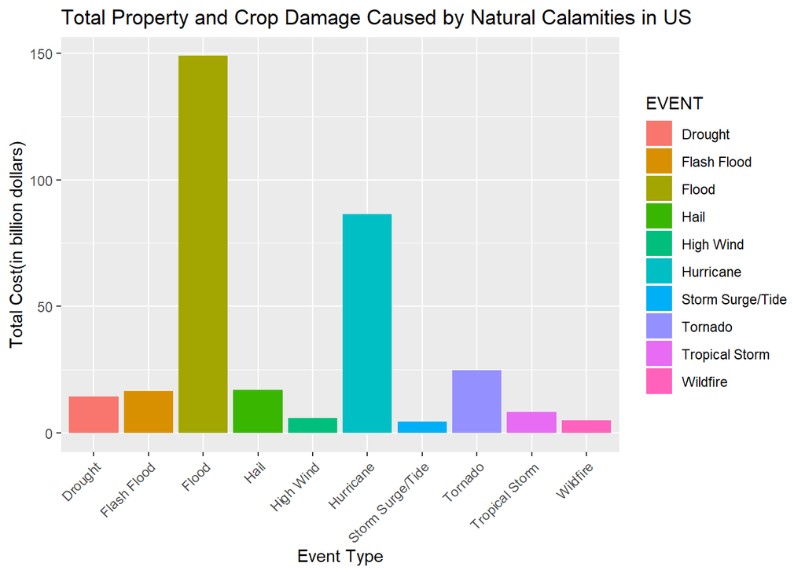

```r
g<-ggplot(total_dmg,aes(x=EVENT,y=total_loss/10^9))
g+geom_bar(aes(fill=EVENT),stat="identity")+labs(x="Event Type",y="Total Cost(in billion dollars)",title = "Total Property and Crop Damage Caused by Natural Calamities in US")+theme(axis.text.x = element_text(angle=45, hjust=1))
```

### Conclusion

1.From the 1st plot we can establish that the TORNADO is the most harmful event to population health.

2.From the 2nd plot we can observe that the FLOOD is the event that has the greatest economic consequences